# 6. Enkelvoudige lineaire regressie

Author

Lieven Clement

Published

Invalid Date

# 1 Breast cancer dataset

- subset van studie https://doi.org/10.1093/jnci/djj052
- 32 borstkanker patiënten met een estrogen recepter positieve tumor die tamoxifen chemotherapy behandeling ondergaan. Variabelen:
  - grade: histologische graad van tumor (graad 1 vs 3),
  - node: status van de lymfe knopen (0: niet aangetast, 1: aantasting en verwijdering van de lymfe knopen),
  - size: grootte van tumor in cm,
  - ESR1 en S100A8 gen expressie in tumor biopsy (via microarray technologie)

```r
brca <- read_csv("https://raw.githubusercontent.com/statOmics/sbc/master/data/breastcancer.csv")
brca
```

```
# A tibble: 32 × 10
   sample_name filename     treatment    er grade  node  size   age  ESR1 S100A8
   <chr>       <chr>        <chr>     <dbl> <dbl> <dbl> <dbl> <dbl> <dbl>  <dbl>
 1 OXFT_209    gsm65344.ce… tamoxifen     1     3     1   2.5    66 1939.  207.
 2 OXFT_1769   gsm65345.ce… tamoxifen     1     1     1   3.5    86 2752.   37.0
 3 OXFT_2093   gsm65347.ce… tamoxifen     1     1     1   2.2    74  379. 2364.
 4 OXFT_1770   gsm65348.ce… tamoxifen     1     1     1   1.7    69 2532.   23.6
 5 OXFT_1342   gsm65350.ce… tamoxifen     1     3     0   2.5    62  141. 3219.
 6 OXFT_2338   gsm65352.ce… tamoxifen     1     3     1   1.4    63 1495.  108.
 7 OXFT_2341   gsm65353.ce… tamoxifen     1     1     1   3.3    76 3406.   14.0
 8 OXFT_1902   gsm65354.ce… tamoxifen     1     3     0   2.4    61 2813.   68.4
 9 OXFT_1982   gsm65355.ce… tamoxifen     1     1     0   1.7    62  950.   74.2
10 OXFT_5210   gsm65356.ce… tamoxifen     1     3     0   3.5    65 1053.  182.
# ℹ 22 more rows
```

- Om didactische redenen verwijderen we eerst 3 outliers in de S100A8 expressie data.
- In deze studie kan dit echter niet worden verantwoord
- Later in de lessen laten we zien hoe je goed met alle data omgaat.

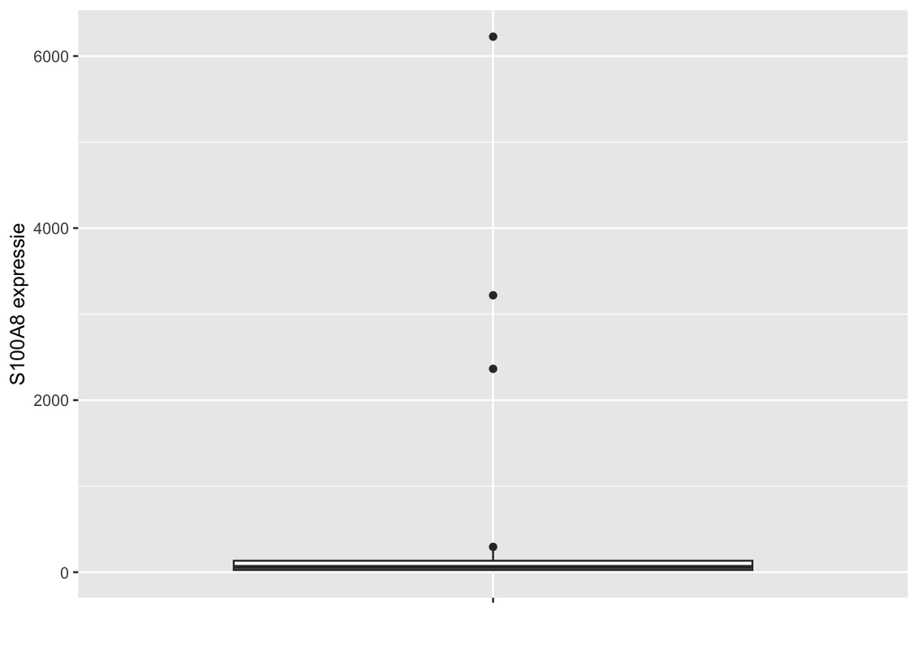

```r
brca |>
  ggplot(aes(x="", y=S100A8)) +
  geom_boxplot() +
  xlab("") +
  ylab("S100A8 expressie")
```

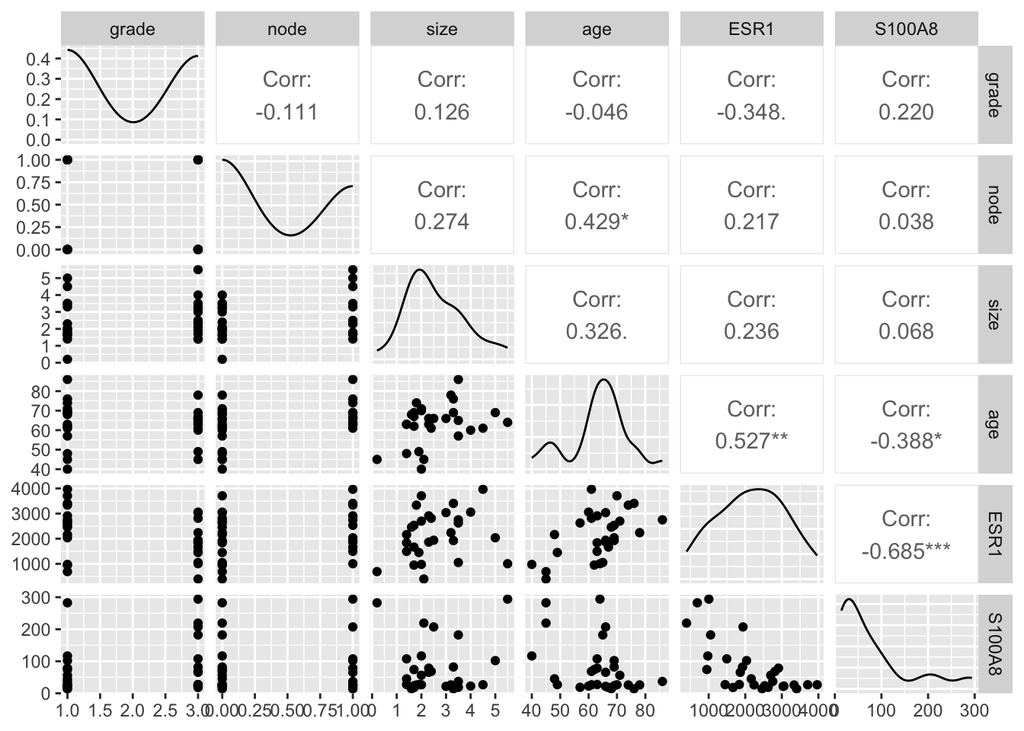

```r
library(GGally)
brcaSubset <- brca |>
  filter(S100A8<2000)
brcaSubset[,-(1:4)] |> ggpairs()
```

## 1.1 Associatie tussen ESR1 en S100A8 expressie

- ESR1 in $\pm$ 75% van borstkankertumoren.
  - Expressie van ER-gen positief voor behandeling: tumor reageert op hormoontherapie
  - Tamoxifen interageert met ER en moduleert genexpressie.
- Eiwitten van de S100-familie zijn vaak gedisreguleerd bij kanker
- S100A8 expressie onderdrukt immuunsysteem in tumor en creëert inflamatoir milieu die kankergroei promoot.
- Interesse in associatie tussen ESR1 en S100A8 expressie.
1. pipe dataset naar ggplot
2. selecteer data `ggplot(aes(x=ESR1,y=S100A8))`
3. voeg punten toe met `geom_point()`
4. voeg een “smooth line” toe `geom_smooth()`

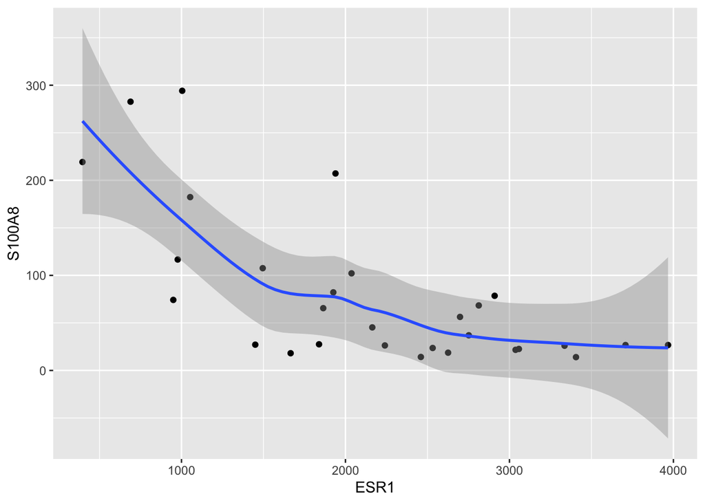

```r
brcaSubset |>
  ggplot(aes(x=ESR1,y=S100A8)) +
  geom_point() +
  geom_smooth()
```

# 2 Lineaire Regressie

- Statistische methode om relatie tussen 2 reeksen observaties $(X_i, Y_i)$, bekomen voor onafhankelijke subjecten $i = 1, ..., n$, te beschrijven.
- Gen expressie voorbeeld
  - Response Y : S100A8 expressie
  - Predictor X: ESR1 expressie
1. pipe dataset naar ggplot
2. selecteer data `ggplot(aes(x=ESR1,y=S100A8))`
3. voeg punten toe met `geom_point()`
4. voeg een “smooth line” toe `geom_smooth()`
5. voeg een rechte toe `geom_smooth()` met `method = "lm"` (linear model). (We zetten `se = FALSE` om geen puntgewijze betrouwbaarheidsintervallen weer te geven)

```r
brcaSubset |>
  ggplot(aes(x = ESR1,y = S100A8)) +
  geom_point() +
  geom_smooth(se = FALSE, col = "grey") +
  geom_smooth(method = "lm", se = FALSE)
```

[output not shown]

## 2.1 Model

- Voor vaste $X$, heeft $Y$ niet noodzakelijke dezelfde waarde

$$\text{observation = signal + noise}$$

$$Y_i=g(X_i)+\epsilon_i$$

- We definiëren $g(x)$ als het verwachte resultaat voor subjects met $X_i=x$

$$E[Y_i|X_i=x]=g(x)$$

Daarom is $\epsilon_i$ gemiddeld 0 voor subjects met dezelfde $X_i$:
$$E[\epsilon_i|X_i]=0$$

## 2.2 Lineaire regressie

- Om **accurate** en **interpreteerbare** resultaten te bekomen, kiest men $g(x)$ vaak als een lineaire functie met ongekende parameters.

$$E(Y|X=x)=\beta_0 + \beta_1 x$$

onbekend **intercept** $\beta_0$ en **helling** $\beta_1$.

- Lineair model legt een *assumptie* op de verdeling van $X$ en $Y$, die incorrect kan zijn.
- *Efficiënte data-analyse*: benut alle observaties om iets te leren over verwachte uitkomst bij $X=x$.

## 2.3 Gebruik

- *Predictie*: wanneer $Y$ ongekend is, maar $X$ wel, kunnen we $Y$ voorspellen op basis van $X$

$$E(Y|X=x)=\beta_0 + \beta_1 x$$

- *Associatie*: biologische relatie tussen variabele $X$ en continue meting $Y$ beschrijven.
- *Intercept:* $E(Y|X=0)=\beta_0$
- *Slope*:
  $$\begin{eqnarray*}
  E(Y|X=x+\delta)-E(Y|X=x)&=&\beta_0 + \beta_1 (x+\delta) -\beta_0-\beta_1 x\\
  &=& \beta_1\delta
  \end{eqnarray*}$$

$\beta_1:$ verschil in gemiddelde uitkomst voor subjecten die verschillen in één eenheid van de predictor $X$.

# 3 Parameterschatting

- - Kleinste kwadraten techniek (Least squares)

```r
brcaSubset |>
  ggplot(aes(x = ESR1, y = S100A8)) +
  geom_point() +
  geom_smooth(se = FALSE, col = "grey") +
  geom_smooth(method = "lm", se = FALSE)
```

[output not shown]

- Parameters $\beta_0$ en $\beta_1$ zijn ongekend
- Parameters schatten op basis van beperkte steekproef
- Best passende lijn
  - Punt op regressielijn voor een gegeven $x_i$: $(x_i, \beta_0 + \beta_1 x_i)$ zo dicht mogelijk bij $(x_i, y_i)$
  - Kies $\beta_0$ en $\beta_1$ zodat de som tussen voorspelde en waargenomen punten zo klein mogelijk wordt.

    $$SSE=\sum_{i=1}^n (y_i-\beta_0-\beta_1 x_i)^2=\sum_{i=1}^n e_i^2$$
- Met $e_i$ de residuen: de verticale afstanden van de observaties tot de gefitte regressierechte

## 3.1 Schatters die SSE minimaliseren

$$\hat{\beta_1}= \frac{\sum\limits_{i=1}^n (y_i-\bar y)(x_i-\bar x)}{\sum\limits_{i=1}^n (x_i-\bar x)^2}=\frac{\mbox{cor}(x,y)s_y}{s_x}$$

$$\hat{\beta_0}=\bar y - \hat{\beta}_1 \bar x$$

- Merk op dat de helling van de kleinste kwadratenlijn evenredig is met de correlatie tussen de uitkomst en de verklarende variabele.

Geschatte lineaire regressiemodel laat toe om:

- verwachte uitkomst te voorspellen voor subjecten met een gegeven waarde $x$ voor de predictor:
  $$\text{E} [ Y | X = x]=\hat{\beta}_0+\hat{\beta}_1x$$
- na te gaan hoeveel uitkomst gemiddeld verschilt tussen 2 groepen subjecten met een verschil van $\delta$ eenheden in de verklarende variabele:

$$\text{E}\left[Y|X=x+\delta\right]-\text{E}\left[Y|X=x\right]= \hat{\beta}_1\delta$$

### 3.1.1 Borstkanker voorbeeld

```r
lm1 <- lm(S100A8 ~ ESR1, brcaSubset)
summary(lm1)
```

```
Call:
lm(formula = S100A8 ~ ESR1, data = brcaSubset)

Residuals:
   Min     1Q Median     3Q    Max
-95.43 -34.81  -6.79  34.23 145.21

Coefficients:
             Estimate Std. Error t value Pr(>|t|)
(Intercept) 208.47145   28.57207   7.296 7.56e-08 ***
ESR1         -0.05926    0.01212  -4.891 4.08e-05 ***
---
Signif. codes:  0 '***' 0.001 '**' 0.01 '*' 0.05 '.' 0.1 ' ' 1

Residual standard error: 59.91 on 27 degrees of freedom
Multiple R-squared:  0.4698,    Adjusted R-squared:  0.4502
F-statistic: 23.93 on 1 and 27 DF,  p-value: 4.078e-05
```

$$E(Y|X=x)=208.47-0.059 x$$

- De verwachte S100A8-expressie is gemiddeld 59 eenheden lager voor patiënten met een ESR1-expressieniveau die 1000 eenheden hoger ligt
- Crossectionele studie dus helling enkel te interpreteren als verschillen tussen groepen patienten!.
- Verwachte S100A8 expressieniveau voor patiënten met een ESR1 expressieniveau van 2000:

$$208.47-0.059\times 2000=89.94$$

- Verwachte S100A8 expressieniveau voor patiënten met een ESR1 expressieniveau van 4000:

$$208.47-0.059\times 4000=-28.58$$

- **Let op voor extrapolatie!** (Veronderstelling van lineariteit kan men enkel nagaan binnen het bereik van de data).

# 4 Statistische besluitvorming (statistische inferentie)

Om besluiten te kunnen trekken over lineaire regressiemodel

$$E(Y|X)=\beta_0+\beta_1 X$$

moeten we weten:

- Hoe de least squares parameter schatters variëren van steekproef tot steekproef, en
- En hoe is dit onder de nulhypothese dat er geen associatie is tussen predictor en response
- Noodzaak aan statistisch model!
- Modelleer de verdeling van $Y$ gegeven $X$ expliciet: $f_{Y|X}(y)$

## 4.1 Modelleer verdeling van Y?

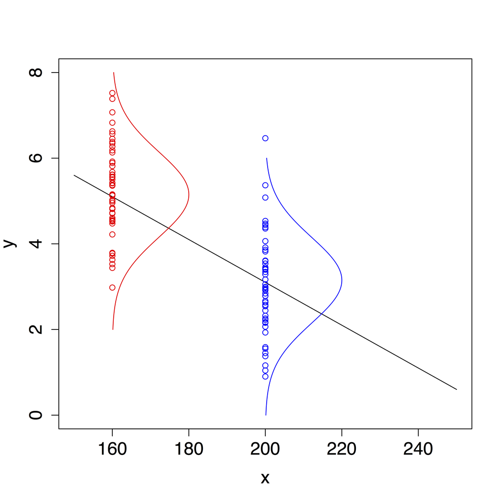

## 4.2 Hoge spreiding op $X$ verbetert de precisie

$$\sigma^2_{\hat{\beta}_1}=\frac{\sigma^2}{\sum\limits_{i=1}^n (X_i-\bar X)^2}$$

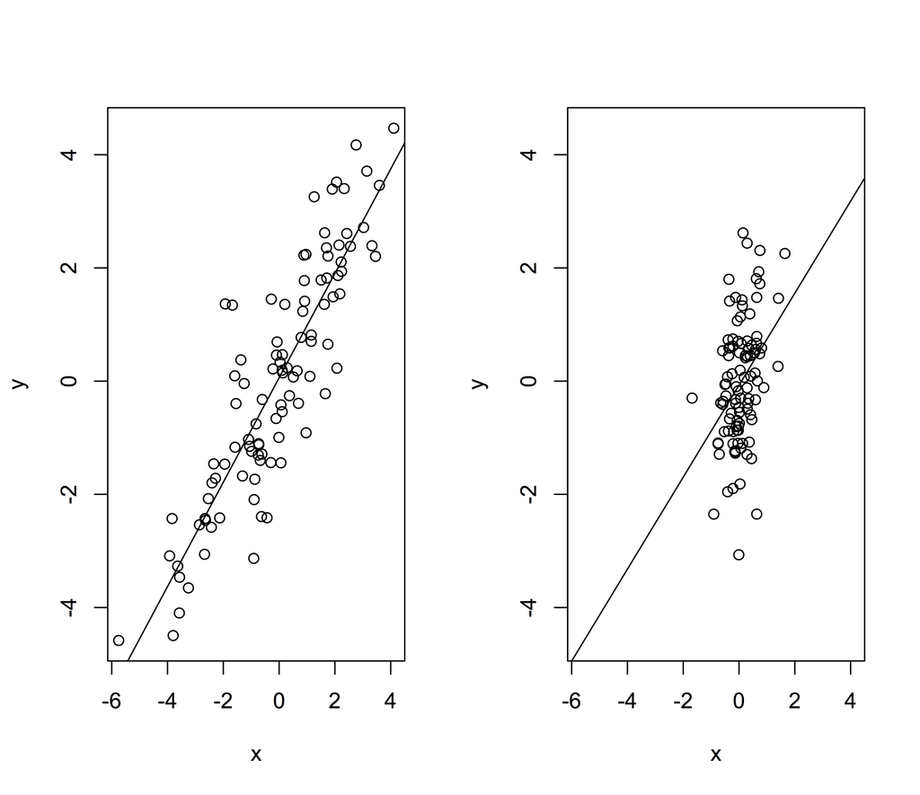

- Conditionele variantie ($\sigma^2$) is niet gekend
- Schatten d.m.v. gemiddelde van die kwadratische afwijkingen rond de regressierechte
- *mean squared error* (MSE)

$$\hat\sigma^2=MSE=\frac{\sum\limits_{i=1}^n \left(y_i-\hat\beta_0-\hat\beta_1\times x_i\right)^2}{n-2}=\frac{\sum\limits_{i=1}^n e^2_i}{n-2}.$$

- Voor het bekomen van deze schatter steunen we op onafhankelijkheid (aanname 2) en homoscedasticiteit (aanname 3).
- deel door $n-2$

Na schatting van $\sigma^2$ bekomen we volgende standaard errors:

$$\text{SE}_{\hat{\beta}_0}=\hat\sigma_{\hat{\beta}_0}=\sqrt{\frac{\sum\limits_{i=1}^n X^2_i}{\sum\limits_{i=1}^n (X_i-\bar X)^2} \times\frac{\text{MSE}}{n}} \text{ en } \text{SE}_{\hat{\beta}_1}=\hat\sigma_{\hat{\beta}_1}=\sqrt{\frac{\text{MSE}}{\sum\limits_{i=1}^n (X_i-\bar X)^2}}$$

- Opnieuw toetsen en betrouwbaarheidsintervallen o.b.v.
  $$T=\frac{\hat{\beta}_k-\beta_k}{SE(\hat{\beta}_k)} \text{ with } k=1,2.$$
- Als aan alle aannames is voldaan volgt $T$ een t-verdeling met n-2 vrijheidsgraden.
- Als geen normaliteit maar wel onafhankelijk, lineariteit en homoscedasticiteit en grote dataset $\rightarrow \text{Centrale Limietstelling}$

### 4.2.1 Borstkanker voorbeeld

- Negatieve associatie tussen S100A8 en ESR1 gen expressie.
- Veralgemeen effect in steekproef naar populatie met behulp van het betrouwbaarheidsinterval op de helling:

$$[\hat\beta_1 - t_{n-2,\alpha/2} \text{SE}_{\hat\beta_1},\hat\beta_1 + t_{n-2,\alpha/2} \text{SE}_{\hat\beta_1}]$$
.

```r
confint(lm1)
```

```
                   2.5 %       97.5 %
(Intercept) 149.84639096 267.09649989
ESR1         -0.08412397  -0.03440378
```

- Negatief verband is significant op het 5% significantieniveau.

## 4.3 Hypothese test

- Vertaal de onderzoeksvraag “Is er een associatie tussen de S100A8- en ESR1-genexpressie?” naar de parameters in het model.
- Onder nulhypothese geen associatie tussen expressie van beide genen:
  $$H_0: \beta_1=0$$
- Onder alternatieve hypothese is er een associatie tussen beide genen:
  $$H_1: \beta_1\neq0$$
- Test statistiek
  $$T=\frac{\hat{\beta}_1-0}{SE(\hat{\beta}_k)}$$
- Onder $H_0$ volgt de statistiek een t-verdeling met n-2 vrijheidsgraden.

### 4.3.1 Brca dataset

```r
summary(lm1)
```

```
Call:
lm(formula = S100A8 ~ ESR1, data = brcaSubset)

Residuals:
   Min     1Q Median     3Q    Max
-95.43 -34.81  -6.79  34.23 145.21

Coefficients:
             Estimate Std. Error t value Pr(>|t|)
(Intercept) 208.47145   28.57207   7.296 7.56e-08 ***
ESR1         -0.05926    0.01212  -4.891 4.08e-05 ***
---
Signif. codes:  0 '***' 0.001 '**' 0.01 '*' 0.05 '.' 0.1 ' ' 1

Residual standard error: 59.91 on 27 degrees of freedom
Multiple R-squared:  0.4698,    Adjusted R-squared:  0.4502
F-statistic: 23.93 on 1 and 27 DF,  p-value: 4.078e-05
```

- Associatie tussen de S100A8 en ESR1 genexpressie extreem significant is (p<<0.001).
- Maar eerst moeten we alle assumpties controleren!
- Anders kunnen de conclusies o.b.v. de statistische test en het BI onjuist zijn.

# 5 Nagaan van modelveronderstellingen

- Onafhankelijkheid: design
- Lineariteit: besluitvorming geen zin als model niet lineair is
- Homoscedasticiteit: besluitvorming/p-waarde is niet betrouwbaar als de data niet homoscedastisch zijn
- Normaliteit: besluitvorming/p-waarde is niet betrouwbaar als de data niet normaal verdeeld zijn in kleine steekproeven

## 5.1 Lineariteit

```r
brcaSubset |>
  ggplot(aes(x = ESR1, y = S100A8)) +
  geom_point() +
  geom_smooth(se = FALSE, col = "grey") +
  geom_smooth(method = "lm", se = FALSE)
```

[output not shown]

## 5.2 Residuplots

- Afwijkingen van lineariteit echter makkelijker opgespoord d.m.v. een *residuplot*. (Zeker als er later meer variabelen zijn in het lineaire model)
- verklarende variabele of predicties $\hat\beta_0+\hat\beta_1 x$ op de $X$-as
- de *residuen* op de $Y$-as
  $$e_i=y_i-\hat{g}(x_i)=y_i-\hat\beta_0-\hat\beta_1\times x_i,$$

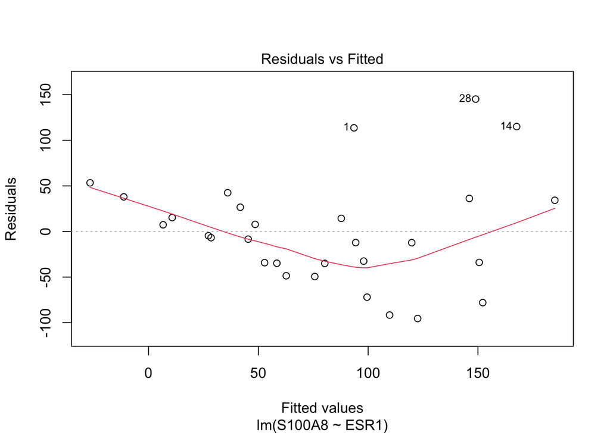

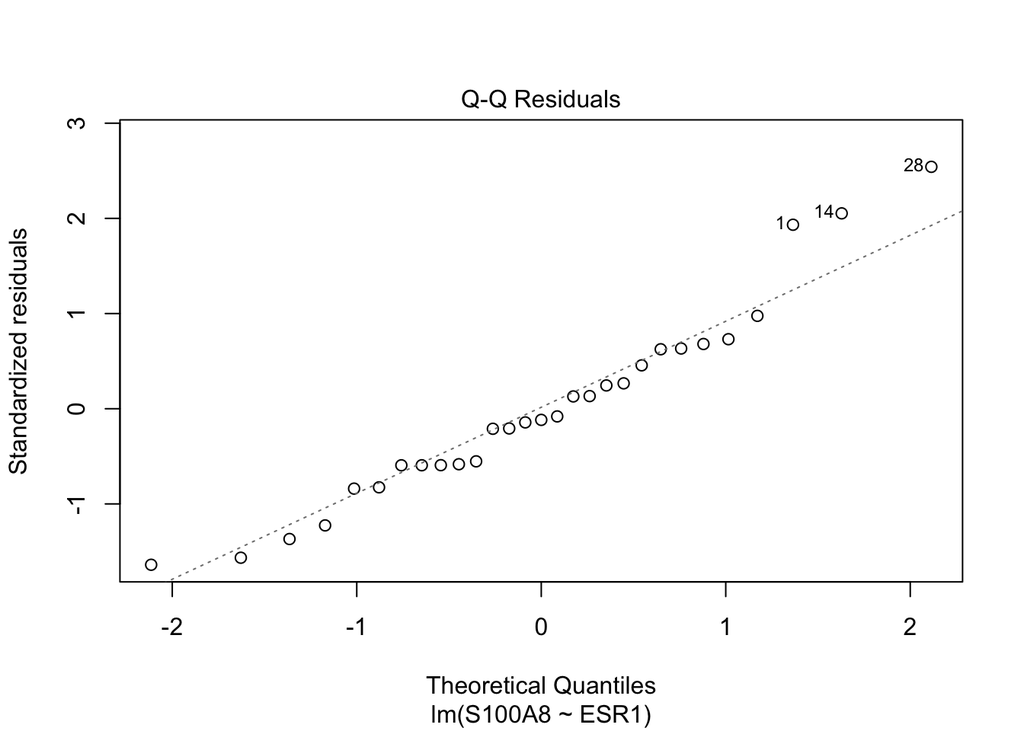

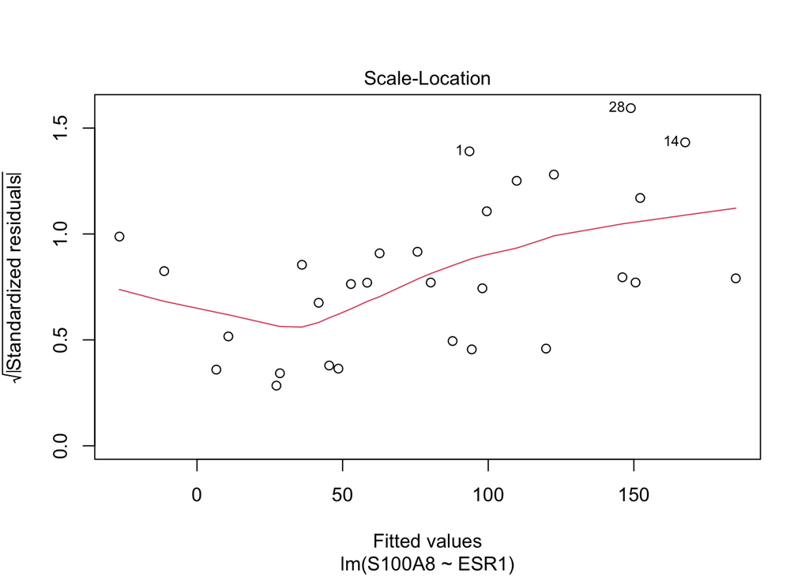

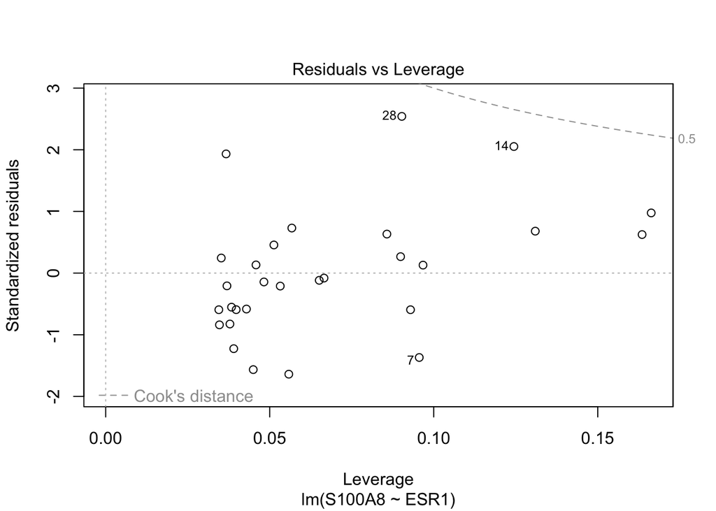

```r
plot(lm1)
```

## 5.3 Homoscedasticiteit (gelijkheid van variantie)

- Residuen en kwadratische residu’s dragen informatie over residuele variabiliteit.
- Associatie met de verklarende variabelen $\rightarrow$ indicatie van heteroscedasticiteit.
- Scatterplot van of $e_i$ versus $x_i$ of predicties $\hat \beta_0+ \hat \beta_1 x_i$.
- Scatterplot van gestandaardiseerd residu versus $x_i$ of predicties.

## 5.4 Normaliteit

- Indien voldoende gegevens, schatters normaal verdeeld zelfs wanneer observaties niet Normaal verdeeld zijn: centrale limiet stelling
- Wat ‘voldoende observaties’ zijn, hangt af van hoe goed de verdeling op de Normale lijkt.
- Aanname is dat uitkomsten Normaal verdeeld zijn bij vaste waarden van de verklarende variabelen.
  $$Y_i\vert X_i\sim N(\beta_0+\beta_1X_i,\sigma^2)$$
- QQ-plot van response Y is heel misleidend.
- QQ-plot van de residuen $e_i$

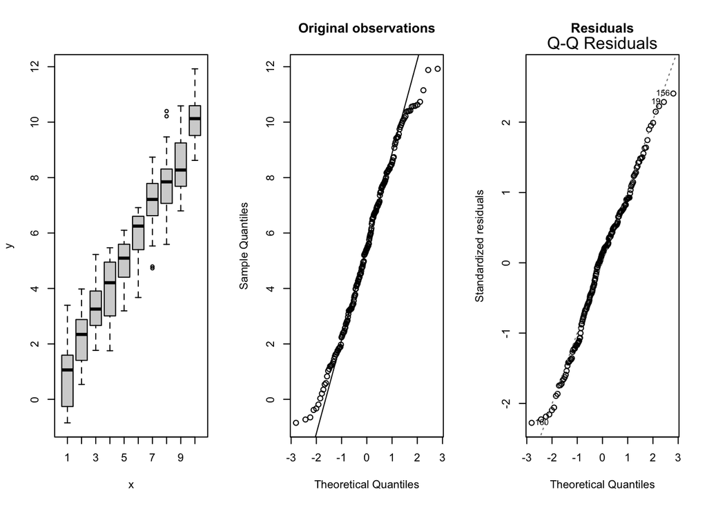

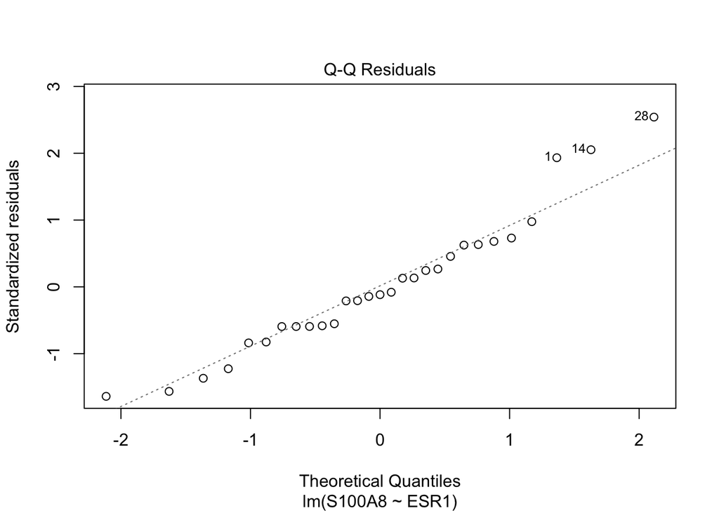

```r
plot(lm1, which=2)
```

# 6 Afwijkingen van Modelveronderstellingen

- Transformatie van onafhankelijke veranderlijke wijzigt de verdeling van Y bij gegeven X niet:
  - helpt niet om normaliteit of homoscedasticiteit te bekomen
  - helpt wel om lineariteit te bekomen wanneer er normaliteit en homoscedasticiteit is
  - Vaak ook hogere orde termen: $X^2$, $X^3$, …
    $$Y_i=\beta_0+\beta_1X_i+\beta_2X_i^2+ ... + \epsilon_i$$
- Transformatie van response Y kan helpen om normaliteit en homoscedasticiteit te bekomen.
  - $\sqrt(Y)$, $\log(Y)$, 1/Y, …

## 6.1 Borstkanker voorbeeld

Problemen met

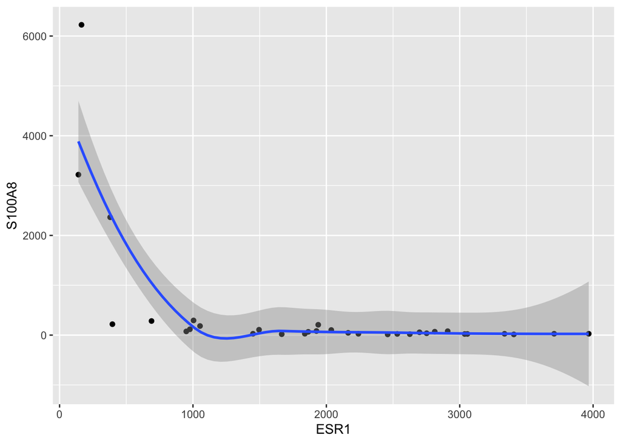

```r
brca |>
  ggplot(aes(x = ESR1, y = S100A8)) +
  geom_point() +
  geom_smooth()
```

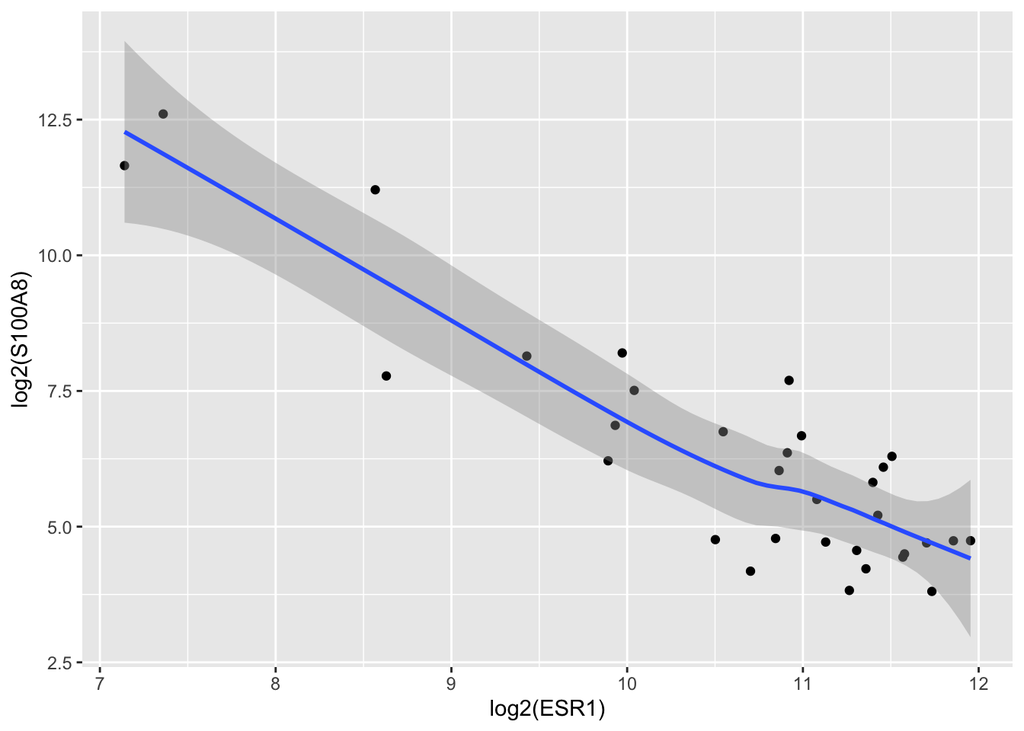

```r
brca |>
  ggplot(aes(
    x = ESR1 |> log2(),
    y = S100A8 |> log2())
    ) +
  geom_point() +
  geom_smooth()
```

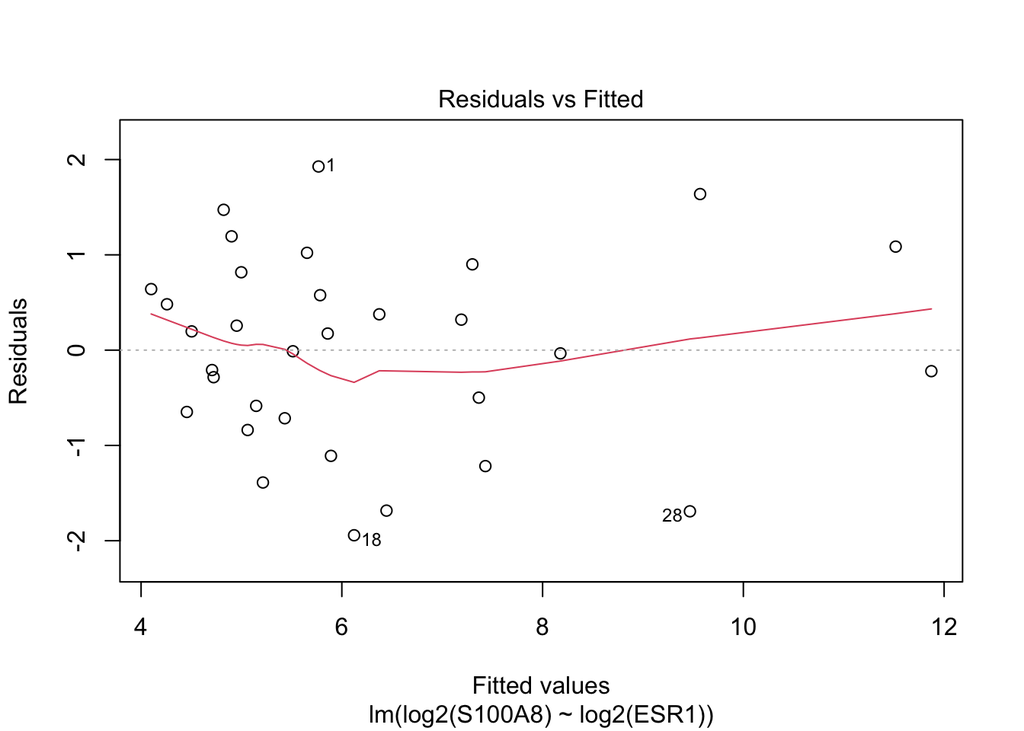

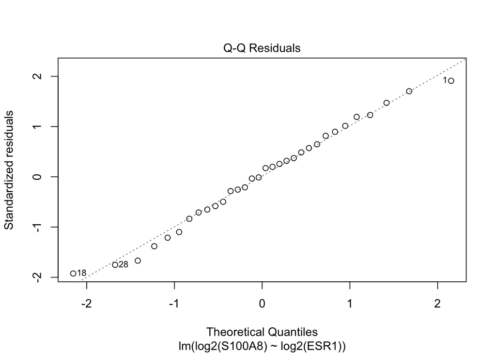

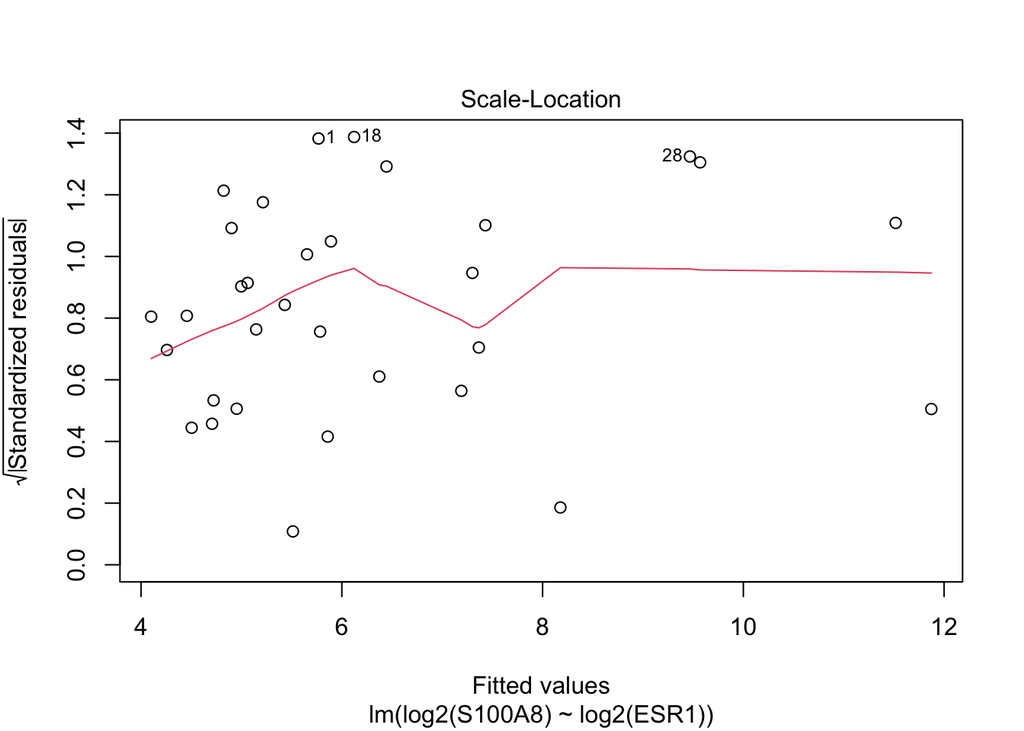

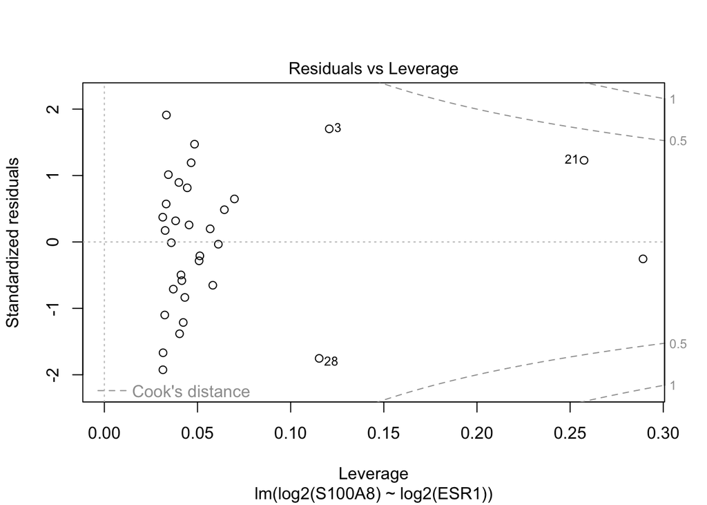

```r
lm2<-lm(S100A8 |> log2() ~ ESR1 |> log2(), brca)
plot(lm2)
```

```r
summary(lm2)
```

```
Call:
lm(formula = log2(S100A8) ~ log2(ESR1), data = brca)

Residuals:
     Min       1Q   Median       3Q      Max
-1.94279 -0.66537  0.08124  0.68468  1.92714

Coefficients:
            Estimate Std. Error t value Pr(>|t|)
(Intercept)   23.401      1.603   14.60 3.57e-15 ***
log2(ESR1)    -1.615      0.150  -10.76 8.07e-12 ***
---
Signif. codes:  0 '***' 0.001 '**' 0.01 '*' 0.05 '.' 0.1 ' ' 1

Residual standard error: 1.026 on 30 degrees of freedom
Multiple R-squared:  0.7942,    Adjusted R-squared:  0.7874
F-statistic: 115.8 on 1 and 30 DF,  p-value: 8.07e-12
```

```r
confint(lm2)
```

```
                2.5 %    97.5 %
(Intercept) 20.128645 26.674023
log2(ESR1)  -1.921047 -1.308185
```

### 6.1.1 Interpretatie 1 / algemeen, in schaal waarin data gemodelleerd zijn

Een patiënt met een ESR1 expressie die 1 eenheid op de $\log_2$ schaal hoger ligt dan dat van een andere patiënt heeft gemiddeld gezien een expressie-niveau van het S100A8 gen dat 1.61 eenheden lager ligt (95% BI [-1.92,-1.31]).

**Crossectionele studie: enkel uitspraken over verschillen tussen patiënten!**

$$\log_2 \hat\mu_1=23.401 -1.615 \times \text{logESR}_1,\text{ } \log_2 \hat\mu_2=23.401 -1.615 \times \text{logESR}_2$$
$$\log_2 \hat\mu_2-\log_2 \hat\mu_1= -1.615 (\log_2 \text{ESR}_2-\log_2 \text{ESR}_1) = -1.615 \times 1 = -1.615$$

### 6.1.2 Interpretatie 2 / specifiek door gebruik te maken van de transformatie van de variabelen

Model op log-schaal: bij terugtransformatie verkrijgen we het geometrische gemiddelde

$$\begin{eqnarray*}
\sum\limits_{i=1}^n \frac{\log x_i}{n}&=&\frac{\log x_1 + \ldots + \log x_n}{n}\\\\
&\stackrel{(1)}{=}&\frac{\log(x_1 \times \ldots \times x_n)}{n}=\frac{\log\left(\prod\limits_{i=1}^n x_i\right)}{n}\\\\
&\stackrel{(2)}{=}&\log \left(\sqrt[\leftroot{-1}\uproot{2}\scriptstyle n]{\prod\limits_{i=1}^n x_i}\right)
\end{eqnarray*}$$

- Populatiegemiddelden $\mu$ dus geschat a.d.h.v. geometrisch gemiddelden.
- Logaritmische transformatie is een monotoon: we kunnen betrouwbaarheidsintervallen berekend op log-schaal terugtransformeren!

```r
2^lm2$coef[2]
```

```
log2(ESR1)
 0.3265519
```

```r
2^-lm2$coef[2]
```

```
log2(ESR1)
    3.0623
```

```r
2^-confint(lm2)[2,]
```

```
   2.5 %   97.5 %
3.786977 2.476298
```

Een patiënt met een ESR1 expressie die 2 keer zo hoog is als die van een andere patiënt, zal gemiddeld een S100A8-expressie hebben die 3.06 keer lager is (95% BI [2.48,3.79]).

$$\log_2 \hat\mu_1=23.401 -1.615 \times \text{logESR}_1,\text{ } \log_2 \hat\mu_2=23.401 -1.615 \times \text{logESR}_2$$
$$\log_2 \hat\mu_2-\log_2 \hat\mu_1= -1.615 (\log_2 \text{ESR}_2-\log_2 \text{ESR}_1)$$
$$\log_2 \left[\frac{\hat\mu_2}{\hat\mu_1}\right]= -1.615 \log_2\left[\frac{ \text{ESR}_2}{\text{ESR}_1}\right]$$
$$\frac{\hat\mu_2}{\hat\mu_1}=\left[\frac{ \text{ESR}_2}{\text{ESR}_1}\right]^{-1.615}=2^ {-1.615} =0.326$$
or
$$\frac{\hat\mu_1}{\hat\mu_2}=2^{1.615} =3.06$$

### 6.1.3 Interpratie 3 / Enkel bij log-transformatie van zowel response als predictor variabelen

Een patiënt met een ESR1 expressie die 1% hoger is dan die van een andere patiënt zal gemiddeld een expressieniveau voor het S100A8 gen hebben dat ongeveer -1.61% lager is (95% BI [-1.92,-1.31])%.

$$\log_2 \hat\mu_1=23.401 -1.615 \times \text{logESR}_1,\text{ } \log_2 \hat\mu_2=23.401 -1.615 \times \text{logESR}_2$$
$$\log_2 \hat\mu_2-\hat\log_2 \mu_1= -1.615 (\log_2 \text{ESR}_2-\log_2 \text{ESR}_1)$$
$$\log_2 \left[\frac{\hat\mu_2}{\hat\mu_1}\right]= -1.615 \log_2\left[\frac{ \text{ESR}_2}{\text{ESR}_1}\right]$$
$$\frac{\hat\mu_2}{\hat\mu_1}=\left[\frac{ \text{ESR}_2}{\text{ESR}_1}\right]^{-1.615}=1.01^ {-1.615} =0.984 \approx -1.6\%$$

Dit geldt voor lage tot matige waarden van $\beta_1$:
$$-10<\beta_1<10 \rightarrow 1.01^{\beta_1} -1 \approx \frac{\beta_1}{100}.$$

# 7 Besluitvorming over gemiddelde uitkomst

- Regressie model kan ook worden gebruikt voor predictie
- Om besluitvorming te doen over de gemiddelde uitkomst bij een gegeven waarde $x$, m.a.w.
  $$\hat{g}(x)= \hat{\beta}_0 + \hat{\beta}_1 x$$
- $\hat{g}(x)$ een schatter van het conditionele gemiddelde $E[Y\vert X=x]$
- Parameterschatters Normale verdeeld en onvertekend $\rightarrow$ schatter $\hat{g}(x)$ ook Normaal verdeeld en onvertekend. SE?
- Predictie voor een nieuwe variabele is een lineare combinatie van helling en intercept: $\hat{\beta}_0 + \hat{\beta}_1 x = L^T\hat{\boldsymbol{\beta}}$ met L = $\left[\begin{matrix}1\\x\end{matrix}\right]$.

$$\text{Var}\left(\mathbf{L}^T\hat{\boldsymbol{\beta}}\right)=\mathbf{L}^T\Sigma_{\hat{\boldsymbol{\beta}}}\mathbf{L}$$

$$\Sigma_{\hat{\boldsymbol{\beta}}}
=\left[\begin{matrix}
\dfrac{\sum\limits_{i=1}^n X_i^2}{n\sum\limits_{i=1}^n (X_i-\bar X)^2}\,\sigma^2
& -\dfrac{\bar X}{\sum\limits_{i=1}^n (X_i-\bar X)^2}\,\sigma^2 \\[2.5ex]
-\dfrac{\bar X}{\sum\limits_{i=1}^n (X_i-\bar X)^2}\,\sigma^2
& \dfrac{\sigma^2}{\sum\limits_{i=1}^n (X_i-\bar X)^2}
\end{matrix}\right]$$

$$\text{Var}\left(L^T\hat{\boldsymbol\beta}\right)
= L^T \,\text{Var}(\hat{\boldsymbol\beta})\, L
= \left[\begin{matrix}1 & x\end{matrix}\right]
\left[\begin{matrix}
\dfrac{\sum\limits_{i=1}^n X_i^2}{n\sum\limits_{i=1}^n (X_i-\bar X)^2}\,\sigma^2
& -\dfrac{\bar X}{\sum\limits_{i=1}^n (X_i-\bar X)^2}\,\sigma^2 \\[2.5ex]
-\dfrac{\bar X}{\sum\limits_{i=1}^n (X_i-\bar X)^2}\,\sigma^2
& \dfrac{\sigma^2}{\sum\limits_{i=1}^n (X_i-\bar X)^2}
\end{matrix}\right]
\left[\begin{matrix}1\\x\end{matrix}\right]$$

$$= \sigma^2\left[\dfrac{\sum\limits_{i=1}^n X_i^2}{n\sum\limits_{i=1}^n (X_i-\bar X)^2}
- \dfrac{2x\bar X}{\sum\limits_{i=1}^n (X_i-\bar X)^2}
+ \dfrac{x^2}{\sum\limits_{i=1}^n (X_i-\bar X)^2}\right]$$

Gebruik makend van $\dfrac{\sum_i X_i^2}{n}=\bar X^2+\dfrac{\sum_i(X_i-\bar X)^2}{n}$ herleidt dit tot:

$$\text{Var}\left(L^T\hat{\boldsymbol\beta}\right)
= \sigma^2\left\{\dfrac{1}{n}+\dfrac{(x-\bar X)^2}{\sum\limits_{i=1}^n (X_i-\bar X)^2}\right\}$$

- Als we hiervan de vierkantswortel trekken en de variantie vervangen door zijn schatter MSE bekomen we:

$$\text{SE}_{\hat{g}(x)}=\sqrt{MSE\left\{\frac{1}{n}+\frac{(x-\bar X)^2}{\sum\limits_{i=1}^n (X_i-\bar X)^2}\right\}}.$$

- Bijgevolg kunnen we dan volgende t-test statistiek gebruiken

$$T=\frac{\hat{g}(x)-g(x)}{SE_{\hat{g}(x)}}\sim t_{n-2}$$

- Gemiddelde uitkomst en betrouwbaarheidsintervallen op de gemiddelde uitkomst in R via de `predict(.)` functie.
- `newdata` argument: predictorwaarden (x-waarden) voor het berekenen van gemiddelde uitkomsten
- `interval="confidence"` argument om betrouwbaarheidsintervallen te bekomen.
- Zonder `newdata` argument wordt de gemiddelde uitkomsten berekend voor alle predictorwaarden van de dataset.

```r
grid <- 140:4000
g <- predict(
  lm2,
  newdata = data.frame(ESR1 = grid),
  interval = "confidence")
head(g)
```

```
       fit      lwr      upr
1 11.89028 10.76082 13.01974
2 11.87370 10.74721 13.00019
3 11.85724 10.73370 12.98078
4 11.84089 10.72028 12.96151
5 11.82466 10.70696 12.94237
6 11.80854 10.69372 12.92336
```

Merk op dat we de nieuwe data die we gespecificeerd hebben voor de ESR1 expressie niet moeten transformeren omdat we het model fitten met de `lm`functie en de transformatie hebben gespecificeerd binnen die functie met behulp van het pipe commando!

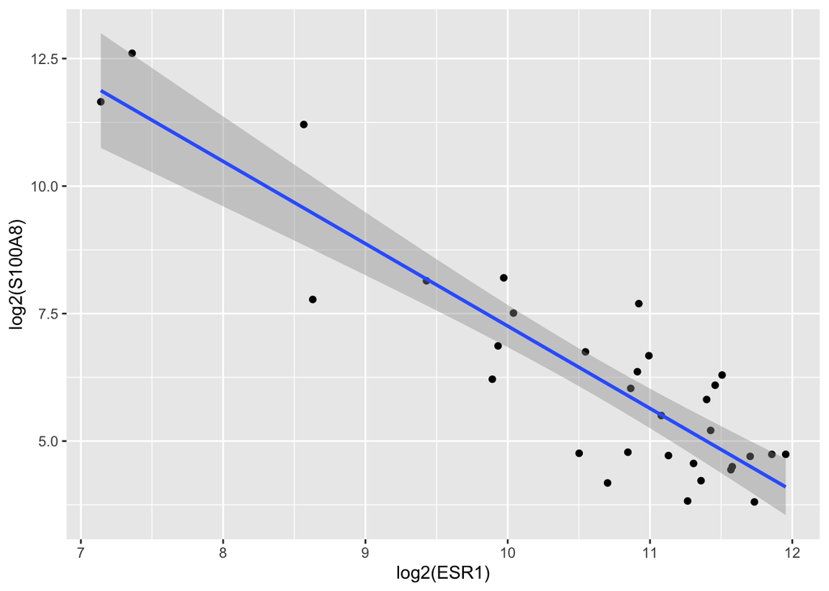

```r
brca |> ggplot(
  aes(
    x = ESR1 |> log2(),
    y = S100A8 |> log2())
  ) +
  geom_point() +
  geom_smooth(method = "lm")
```

## 7.1 Terugtransformatie

- Terug transformatie van BI’s is mogelijk omdat de log-transformatie monotoon is!

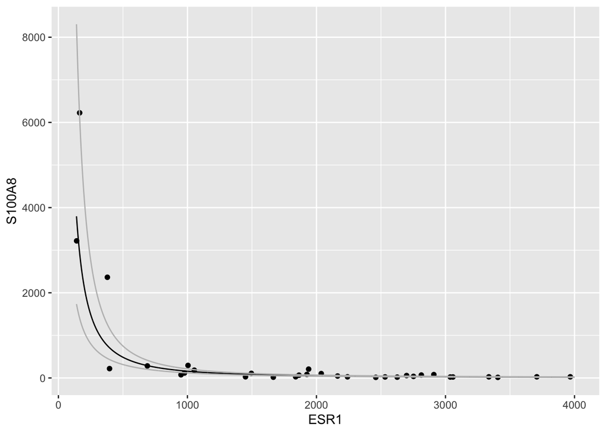

```r
newdata<-data.frame(cbind(grid,2^g))
brca |>
  ggplot(aes(x = ESR1, y = S100A8)) +
  geom_point() +
  geom_line(aes(x=grid,y=fit),newdata) +
  geom_line(aes(x=grid,y=lwr),newdata,color="grey") +
  geom_line(aes(x=grid,y=upr),newdata,color="grey")
```

# 8 Predictie-intervallen

-We kunnen ook een voorspelling doen voor de locatie van een nieuwe waarneming die zou worden verzameld in een nieuw experiment voor een patiënt met een bepaalde waarde voor hun ESR1-expressie

- Het is belangrijk op te merken dat dit experiment nog moet worden uitgevoerd. We willen dus de niet-waargenomen individuele expressiewaarde voor een nieuwe patiënt voorspellen.
- Voor een nieuwe onafhankelijke waarneming $Y^*$
  $$Y^* = g(x) + \epsilon^*$$
  met $\epsilon^*\sim N(0,\sigma^2)$ en $\epsilon^*$ onafhankelijk van de waarnemingen in de steekproef $Y_1,\ldots, Y_n$.
- We voorspellen een nieuwe log-S100A8 voor een patiënt met een gekend log2-ESR1-expressieniveau x

$$\hat{y}(x)=\hat{\beta}_0+\hat{\beta}_1 \times x$$

- De geschatte gemiddelde uitkomst en voorspelling voor een nieuwe waarneming zijn gelijk.
- Maar hun steekproef verdelingen zijn anders!
  - Onzekerheid over de geschatte gemiddelde uitkomst $\leftarrow$ onzekerheid over de geschatte modelparameters $\hat\beta_0$ en $\hat\beta_1$.
  - Onzekerheid over nieuwe waarneming $\leftarrow$ *onzekerheid over geschat gemiddelde* en *extra onzekerheid* omdat de nieuwe waarneming zal afwijken rond het gemiddelde!

$$\text{SE}_{\hat{Y}(x)}=\sqrt{\hat\sigma^2+\hat\sigma^2_{\hat{g}(x)}}=\sqrt{MSE\left\{1+\frac{1}{n}+\frac{(x-\bar X)^2}{\sum\limits_{i=1}^n (X_i-\bar X)^2}\right\}}.$$

$$\frac{\hat{Y}(x)-Y}{\text{SE}_{\hat{Y}(x)}}\sim t_{n-2}$$

- Merk op dat een **predictie-interval** (PI) een verbeterde versie is van een referentie-interval wanneer de modelparameters onbekend zijn: onzekerheid over modelparameters + t-verdeling.

```r
p <- predict(
  lm2,
  newdata = data.frame(ESR1 = grid),
  interval="prediction")

head(p)
```

```
       fit      lwr      upr
1 11.89028 9.510524 14.27004
2 11.87370 9.495354 14.25205
3 11.85724 9.480288 14.23419
4 11.84089 9.465324 14.21646
5 11.82466 9.450461 14.19886
6 11.80854 9.435698 14.18138
```

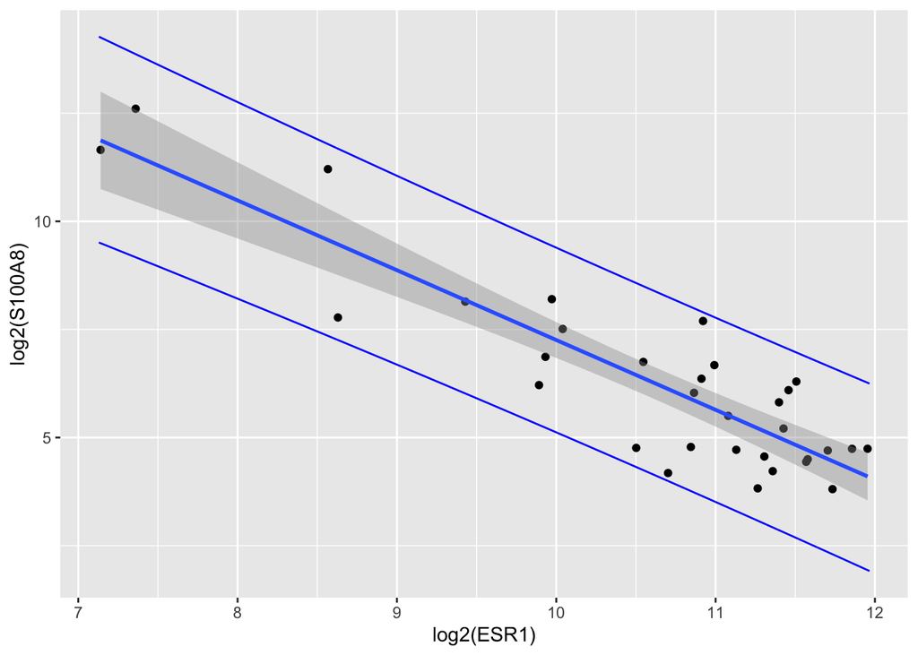

```r
preddata<-data.frame(
  grid = grid|>log2(),
  p)
brca |> ggplot(aes(x=ESR1|>log2(),y=S100A8|>log2())) +
  geom_point() +
  geom_smooth(method="lm") +
     geom_line(aes(x=grid,y=lwr),preddata,color="blue") +
  geom_line(aes(x=grid,y=upr),preddata,color="blue")
```

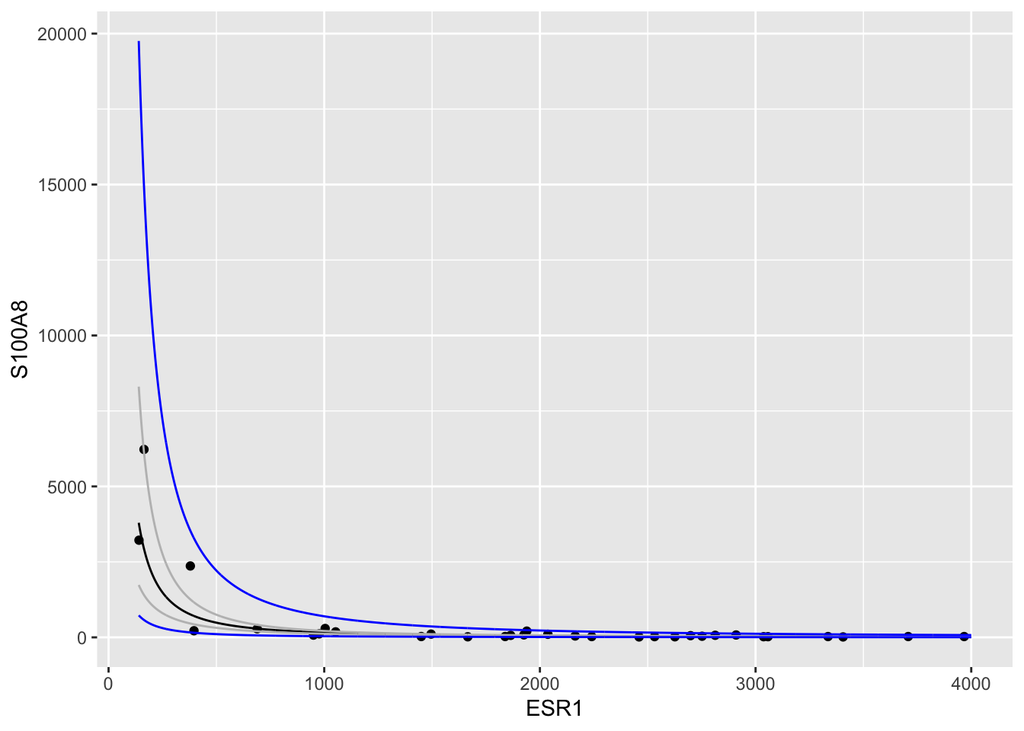

```r
preddata<-data.frame(cbind(grid,2^p))
brca |> ggplot(aes(x = ESR1, y = S100A8)) +
  geom_point() +
  geom_line(
    aes(x = grid,y = fit),
    newdata) +
  geom_line(
    aes(x = grid, y = lwr),
    newdata,
    color = "grey") +
  geom_line(
    aes(x = grid, y = upr),
    newdata,
    color = "grey") +
  geom_line(
    aes(x = grid, y = lwr),
    preddata,
    color = "blue") +
  geom_line(
    aes(x = grid,y = upr),
    preddata,
    color = "blue")
```

## 8.1 NHANES voorbeeld

- Vergelijk referentie-interval voor cholesterolgehalte met predictie interval.
- Referentie-interval

```r
library(NHANES)
fem <- NHANES |>
  filter(Gender=="female"&!is.na(DirectChol))

2^(
  fem |>
  pull(DirectChol) |>
  log2() |>
  mean() +
    c(-1,1) *
    qnorm(0.975) *
    (fem |>
      pull(DirectChol) |>
      log2() |>
      sd())
  )
```

```
[1] 0.8361311 2.4397130
```

- Predictie interval

```r
lmChol <- lm(DirectChol |> log2() ~ 1, data=fem)
predInt <- predict(
  lmChol,
  interval="prediction",
  newdata=data.frame(noPred=1)
  )
round(2^predInt,2)
```

```
   fit  lwr  upr
1 1.43 0.84 2.44
```

Merk op dat het voorspellingsinterval bijna gelijk is aan het referentie-interval voor de grote steekproef. We konden de parameters inderdaad heel precies schatten.

We zullen hetzelfde doen voor een kleine steekproef van 10 patiënten.

- Referentie interval

```r
set.seed(1)
fem10 <- NHANES |>
  filter(Gender=="female"&!is.na(DirectChol)) |>
  sample_n(size=10)

2^(
  fem10 |>
    pull(DirectChol) |>
    log2() |>
    mean() +
      c(-1,1) *
      qnorm(0.975) *
      (fem10 |>
        pull(DirectChol) |>
        log2() |>
        sd())
  )
```

```
[1] 0.8976012 2.2571645
```

- Predictie interval

```r
lmChol10 <- lm(DirectChol |> log2() ~ 1, data = fem10)
predInt10 <- predict(
  lmChol10,
  interval = "prediction",
  newdata = data.frame(noPred=1)
  )
round(2^predInt10, 2)
```

```
   fit  lwr  upr
1 1.42 0.81 2.49
```

# 9 Kwadratensommen en Anova-tabel

## 9.1 Totale kwadratensom

$$\text{SSTot} = \sum_{i=1}^n (Y_i-\bar{Y})^2.$$

- SStot kan worden gebruikt om de variantie van de **marginale verdeling** van de respons te schatten.
- In dit hoofdstuk hebben we ons gefocused op de **conditionele verdeling** $f(Y\vert X=x)$.
- We weten dat MSE een goede schatting is van de variantie van de conditionele verdeling van $Y\vert X=x$.

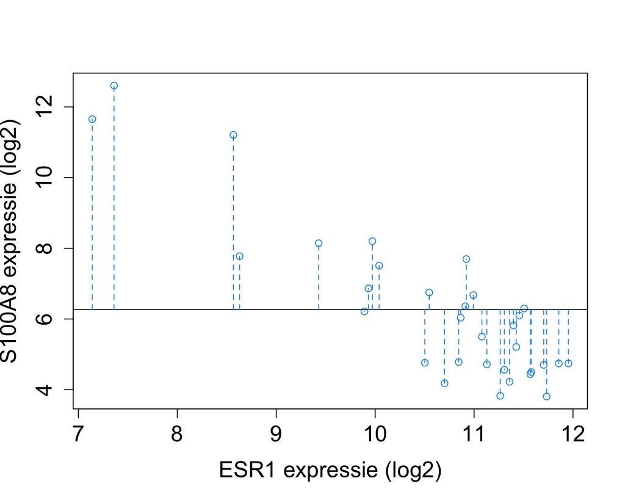

## 9.2 Kwadratensom van de regressie SSR

$$\text{SSR} = \sum_{i=1}^n (\hat{Y}_i - \bar{Y})^2 = \sum_{i=1}^n (\hat{g}(x_i) - \bar{Y})^2.$$

- Maat voor de afwijking tussen de predicties op de geschatte regressierechte en het steekproefgemiddelde van de uitkomsten.
- Een andere interpretatie: verschil tussen twee modellen
  - Geschatte model $\hat{g}(x)=\hat\beta_0+\hat\beta_1x$
  - Geschatte model zonder predictor (enkel intercept): $g(x)=\beta_0$ $\rightarrow$ $\beta_0$ zal gelijk zijn aan $\bar{Y}$.
- SSR meet de grootte van het effect van de predictor

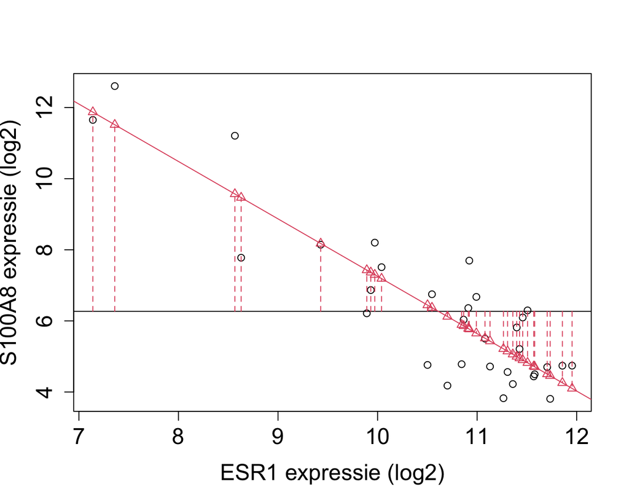

## 9.3 Kwadratensom van de fouten

$$\text{SSE} = \sum_{i=1}^n (Y_i-\hat{Y}_i )^2 = \sum_{i=1}^n \left\{Y_i-\hat{g}\left(x_i\right)\right\}^2.$$

- Hoe kleiner de SSE, hoe beter het model fit.
- Kleinste kwadraten techniek!

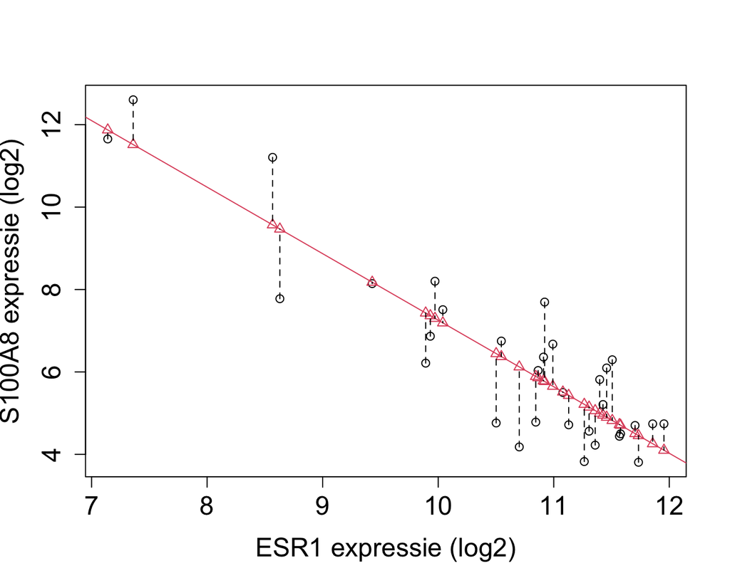

We kunnen aantonen dat SST kan worden ontbonden in
$$\begin{eqnarray*}
\text{SSTot}
&=& \sum_{i=1}^n (Y_i-\bar{Y})^2 \\
&=& \sum_{i=1}^n (Y_i-\hat{Y}_i+\hat{Y}_i-\bar{Y})^2 \\
&=& \sum_{i=1}^n (Y_i-\hat{Y}_i)^2+\sum_{i=1}^n(\hat{Y}_i-\bar{Y})^2 \\
&=& \text{SSE }+\text{SSR}
\end{eqnarray*}$$

- De totale variabiliteit in de gegevens (SSTot) wordt gedeeltelijk verklaard door het regressieverband (SSR).
- Variabiliteit die we niet kunnen verklaren met het regressiemodel is de residuele variabiliteit (SSE).

## 9.4 Determinatie-coëfficiënt

$$R^2 = 1-\frac{\text{SSE}}{\text{SSTot}}=\frac{\text{SSR}}{\text{SSTot}}.$$

- *Fractie van de totale variabiliteit in de steekproef-uitkomsten die verklaard wordt door het geschatte regressieverband*.
- Grote $R^2$ indicatie dat model potentieel tot goede predicties kan leiden (kleine SSE)
- Slechts in beperkte mate indicatief voor de p-waarde van de test $H_0:\beta_1=0$ vs $H_1:\beta_1\neq0$.
  - p-waarde sterk beïnvloed door SSE en steekproefgrootte $n$, maar niet door SSTot
  - De determinatiecoëfficiënt $R^2$ wordt door SSE en SSTot bepaald, maar niet door de steekproefgrootte n.
- Model met lage $R^2$ blijft wel nuttig om associatie te bestuderen, zolang het de associatie correct modelleert!

### 9.4.1 Borstkanker voorbeeld

```r
summary(lm2)
```

```
Call:
lm(formula = log2(S100A8) ~ log2(ESR1), data = brca)

Residuals:
     Min       1Q   Median       3Q      Max
-1.94279 -0.66537  0.08124  0.68468  1.92714

Coefficients:
            Estimate Std. Error t value Pr(>|t|)
(Intercept)   23.401      1.603   14.60 3.57e-15 ***
log2(ESR1)    -1.615      0.150  -10.76 8.07e-12 ***
---
Signif. codes:  0 '***' 0.001 '**' 0.01 '*' 0.05 '.' 0.1 ' ' 1

Residual standard error: 1.026 on 30 degrees of freedom
Multiple R-squared:  0.7942,    Adjusted R-squared:  0.7874
F-statistic: 115.8 on 1 and 30 DF,  p-value: 8.07e-12
```

## 9.5 F-Testen in het enkelvoudig lineair regressiemodel

- Kwadratensommen zijn basis voor $F$-tests
  $$F = \frac{\text{MSR}}{\text{MSE}}$$

met $\text{MSR} = \frac{\text{SSR}}{1} \text{ and } \text{MSE} = \frac{\text{SSE}}{n-2}.$

- MSR wordt de gemiddelde kwadratensom van de regressie genoemd.
- noemers 1 en $n-2$ zijn de vrijheidsgraden van SSR en SSE.
- onder $H_0: \beta_1=0$ volgt de teststatistiek
  $$H_0:F = \frac{\text{MSR}}{\text{MSE}} \sim F_{1,n-2},$$
- F-test is altijd twee-zijdig! $H_1:\beta_1\neq 0$
  $$p = P_0\left[F\geq f\right]=1-F_F(f;1,n-2)$$

```r
summary(lm2)
```

```
Call:
lm(formula = log2(S100A8) ~ log2(ESR1), data = brca)

Residuals:
     Min       1Q   Median       3Q      Max
-1.94279 -0.66537  0.08124  0.68468  1.92714

Coefficients:
            Estimate Std. Error t value Pr(>|t|)
(Intercept)   23.401      1.603   14.60 3.57e-15 ***
log2(ESR1)    -1.615      0.150  -10.76 8.07e-12 ***
---
Signif. codes:  0 '***' 0.001 '**' 0.01 '*' 0.05 '.' 0.1 ' ' 1

Residual standard error: 1.026 on 30 degrees of freedom
Multiple R-squared:  0.7942,    Adjusted R-squared:  0.7874
F-statistic: 115.8 on 1 and 30 DF,  p-value: 8.07e-12
```

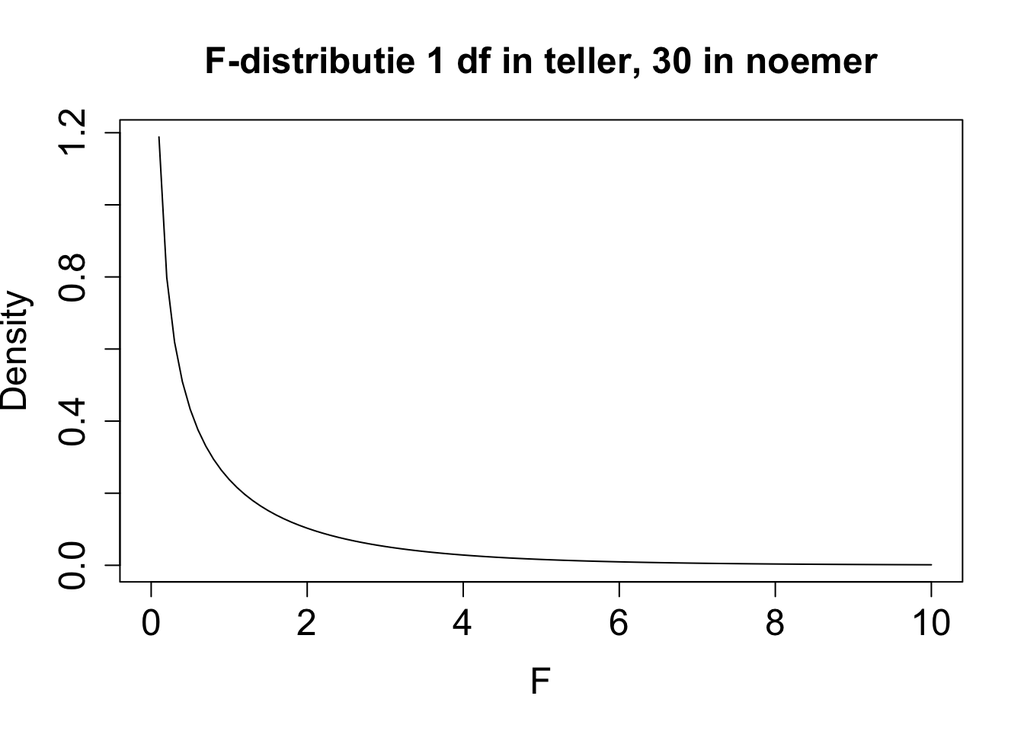

## 9.6 Anova Tabel

|  | Df | Sum Sq | Mean Sq | F value | Pr(>F) |
| --- | --- | --- | --- | --- | --- |
| Regressie | vrijheidsgraden SSR | SSR | MSR | f-statistiek | p-waarde |
| Error | vrijheidsgraden SSE | SSE | MSE |  |  |

```r
anova(lm2)
```

```
Analysis of Variance Table

Response: log2(S100A8)
           Df  Sum Sq Mean Sq F value   Pr(>F)
log2(ESR1)  1 121.814 121.814   115.8 8.07e-12 ***
Residuals  30  31.559   1.052
---
Signif. codes:  0 '***' 0.001 '**' 0.01 '*' 0.05 '.' 0.1 ' ' 1
```

# 10 Dummy variabelen

- Lineaire regressiemodel voor het vergelijken van twee gemiddelden.
- Borstkanker: verschil is in gemiddelde leeftijd van de patiënten met onaangetaste lymfeknopen en patiënten waarvan lymfeknopen werden verwijderd.
- Hiervoor definiëren we eerst een $dummy$ variabele
  $$x_i = \left\{ \begin{array}{ll}
  1 & \text{aangetaste lymfeknopen} \\
  0 & \text{onaangetaste lymfeknopen} \end{array}\right.$$
- groep met $x_i=0$ wordt de **referentiegroep** genoemd.
- Het regressiemodel blijft ongewijzigd,
  $$Y_i = \beta_0 + \beta_1 x_i +\epsilon_i$$
  met $\epsilon_i \text{ iid } N(0,\sigma^2)$

Gezien $x_i$ slechts twee waarden kan aannemen, is het eenvoudig om het regressiemodel voor beide waarden van $x_i$ afzonderlijk te bekijken:
$$\begin{array}{lcll}
Y_i &=& \beta_0 +\epsilon_i &\text{onaangetaste lymfeknopen} (x_i=0) \\
Y_i &=& \beta_0 + \beta_1 +\epsilon_i &\text{ aangetaste lymfeknopen} (x_i=1) .
\end{array}$$

Dus
$$\begin{eqnarray*}
E\left[Y_i\mid x_i=0\right] &=& \beta_0 \\
E\left[Y_i\mid x_i=1\right] &=& \beta_0 + \beta_1,
\end{eqnarray*}$$

waaruit direct de interpretatie van $\beta_1$ volgt:
$$\beta_1 = E\left[Y_i\mid x_i=1\right]-E\left[Y_i\mid x_i=0\right]$$

$\beta_1$ is dus het gemiddelde verschil in leeftijd tussen patiënten met aangetaste lymfeknopen en patiënten met onaangetaste lymfeknopen (referentiegroep).

Met de notatie $\mu_0= E\left[Y_i\mid x_i=0\right]$ en $\mu_1= E\left[Y_i\mid x_i=1\right]$ wordt dit
$$\beta_1 = \mu_1-\mu_0.$$

Er kan aangetoond worden dat
$$\begin{array}{ccll}
\hat\beta_0
&=& \bar{Y}_1&\text{ (steekproefgemiddelde in referentiegroep)} \\
\hat\beta_1
&=& \bar{Y}_2-\bar{Y}_1&\text{(schatter van effectgrootte)} \\
\text{MSE}
&=& S_p^2 .
\end{array}$$

De testen voor $H_0:\beta_1=0$ vs. $H_1:\beta_1\neq0$ kunnen gebruikt worden voor het testen van de nulhypothese van de two-sample $t$-test, $H_0:\mu_1=\mu_2$ t.o.v. $H_1:\mu_1\neq\mu_2$.

```r
brca$node <- as.factor(brca$node)
t.test(age~node,brca,var.equal=TRUE)
```

```
    Two Sample t-test

data:  age by node
t = -2.7988, df = 30, p-value = 0.008879
alternative hypothesis: true difference in means between group 0 and group 1 is not equal to 0
95 percent confidence interval:
 -15.791307  -2.467802
sample estimates:
mean in group 0 mean in group 1
       59.94737        69.07692
```

```r
lm3 <- lm(age~node, brca)
summary(lm3)
```

```
Call:
lm(formula = age ~ node, data = brca)

Residuals:
     Min       1Q   Median       3Q      Max
-19.9474  -5.3269   0.0526   5.3026  18.0526

Coefficients:
            Estimate Std. Error t value Pr(>|t|)
(Intercept)   59.947      2.079  28.834  < 2e-16 ***
node1          9.130      3.262   2.799  0.00888 **
---
Signif. codes:  0 '***' 0.001 '**' 0.01 '*' 0.05 '.' 0.1 ' ' 1

Residual standard error: 9.063 on 30 degrees of freedom
Multiple R-squared:  0.207, Adjusted R-squared:  0.1806
F-statistic: 7.833 on 1 and 30 DF,  p-value: 0.008879
```

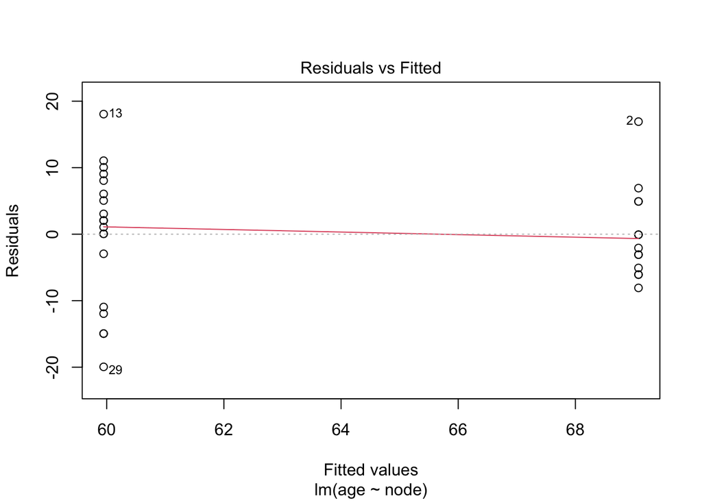

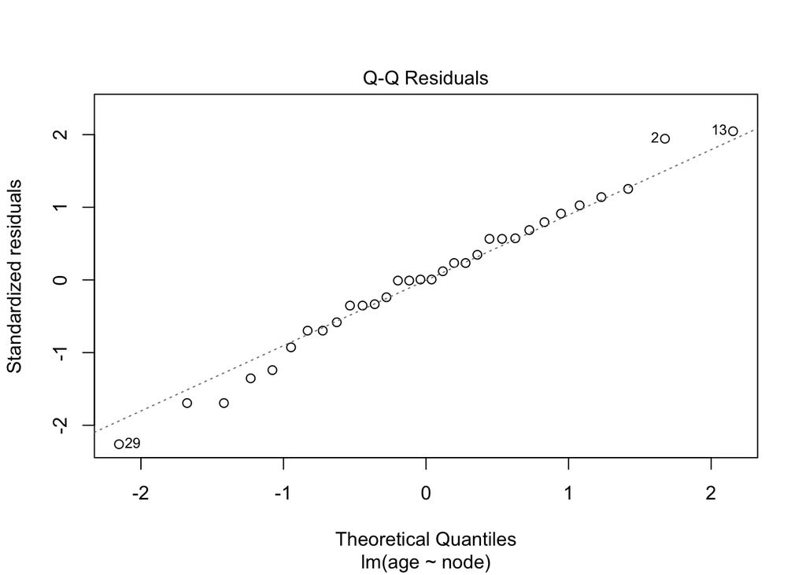

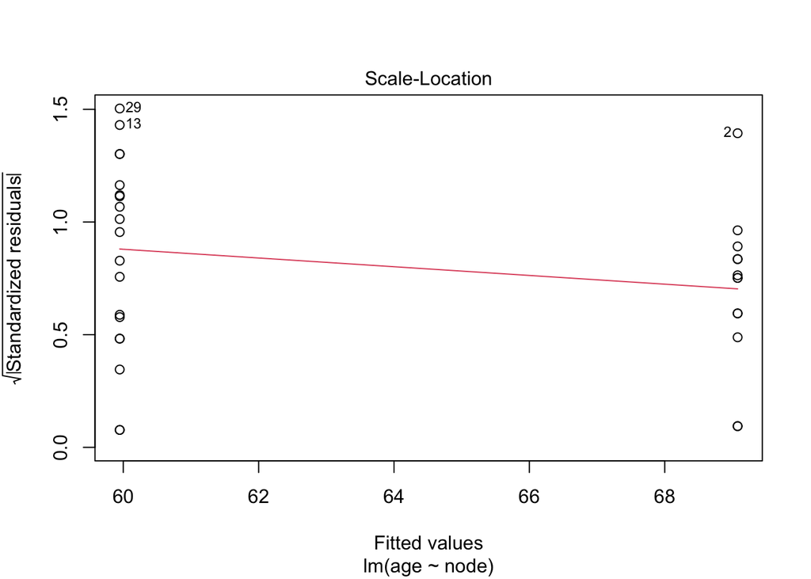

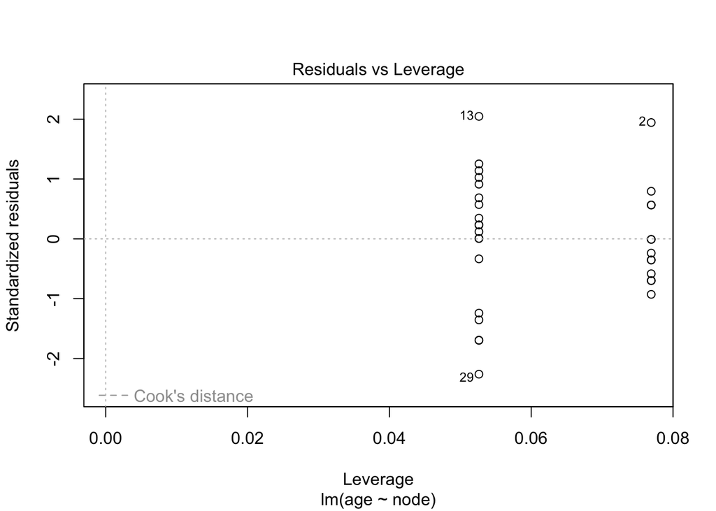

```r
plot(lm3)
```

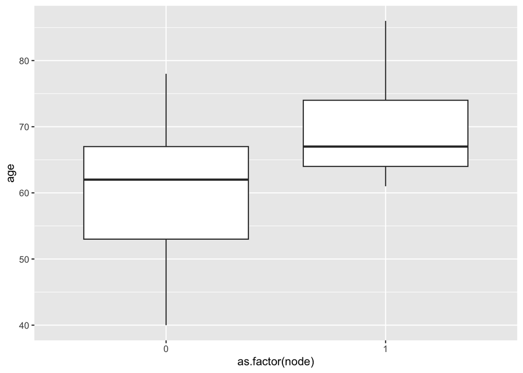

```r
brca |>
  ggplot(
    aes(
      x = node |>
        as.factor(),
      y = age)
      ) +
  geom_boxplot()
```

1. Simulate 9 datasets with the same number of observations as the brca dataset from a normal distribution with the same standard deviation as in the original data. Store the data of all simulations in a data frame
2. Plot the simulated data using the `ggplot` function
3. Add a boxplot layer
4. Use facet_wrap to make a separate plot for simulated dataset
5. Change label of y-axis

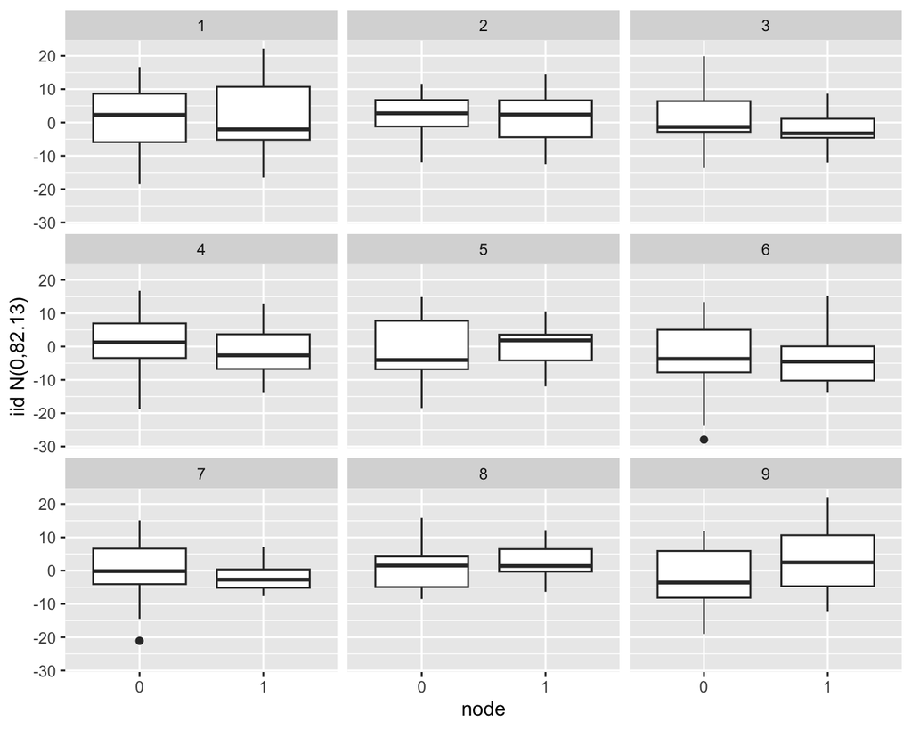

```r
set.seed(354)
sim_df <- data.frame(
  node = rep(brca$node, 9),
  iid = rnorm(9 * nrow(brca), sd = sigma(lm3)),
  sim = rep(1:9, each = 32)
  )
sim_df |>
  ggplot(aes(x = node, y=iid)) +
  geom_boxplot() +
  facet_wrap(.~sim) +
  ylab(paste0("iid N(0,",round(sigma(lm3)^2,2),")"))
```

## 10.1 Observationele study

- We kunnen echter niet besluiten dat oudere personen een hoger risico hebben op aantasting van de lymfeknopen ten gevolge van hun leeftijd.
- Mogelijks **confounding**: geen randomisatie $\rightarrow$ groepen patiënten met aangetaste lymfeknopen en niet-aangetaste lymfeknopen kunnen nog in andere karakteristieken van elkaar verschillen.
- We kunnen enkel besluiten dat er een associatie is tussen de lymfeknoop status en de leeftijd.
- Het is dus niet noodzakelijkerwijs een causaal verband!
- Is ook zo voor lineair model voor de $\log_2$-S100A8-expressie.
- Aangezien we de ESR1-expressie niet experimenteel vast hebben kunnen leggen, kunnen we niet besluiten dat een hogere ESR1-expressie de S100A8-expressie doet verlagen.
- We kunnen enkel besluiten dat er een negatieve associatie is.
- Om impact van gen te bestuderen op andere genen: knockout mutanten generenen in het labo